# Titanic Data Science Solutions

### Workflow goals

**Classifying**. 我们可能想对我们的样品进行分类或标识。我们可能还想了解不同类与解决方案目标之间的含义或关联.

**Correlating**. 可以根据训练数据集中的可用特性来解决这个问题. 数据集中的哪些特性对我们的解决方案目标有很大的贡献? 统计上说，特征和解决方案目标之间存在相关性? 特征值改变时，解决方案也会改变，反之亦然? 这可以在给定的数据集里对数值和分类特性进行测试. 我们可能还想确定其他特性之间的相关性，而不是为了后续的目标和工作流阶段的生存. 关联某些特性可能有助于创建、完成或纠正特性.

**Converting**(转换).对于建模阶段，需要准备数据。根据模型算法的选择，可能需要将所有的特征转换为数值相等的值。例如，将文本分类值转换为数值.

**Completing**. 数据准备也可能要求我们**估计**一个功能中的任何缺失的值。当没有缺失的值时，模型算法可能工作得最好.

**Correcting**. 我们还可以分析给定的训练数据集，以找出错误或可能在特性中存在的值，并试图将这些值识别或排除包含错误的样本. 一种方法是检测我们的示例或特性中的任何异常值. 如果不利于分析或者可能严重歪曲结果，我们也可能完全抛弃一个特性.

**Creating**. 我们可以根据现有的特性或一组特性来创建新特性，这样新特性就会遵循相关、转换和完整性目标.

**Charting**. 如何选择正确的可视化图和图表,根据数据的性质和解决方案的目标.

### Best practices

- 在项目早期执行特性相关分析
- 使用多个图而不是覆盖为了可读性

```python
# data analysis and wrangling
import pandas as pd
import numpy as np
import random as rnd

# visualization
import seaborn as sns
import matplotlib.pylab as plt
%matplotlib inline

# machine learning
from sklearn.linear_model import LogisticRegression
from sklearn.svm import SVC, LinearSVC
from sklearn.ensemble import RandomForestClassifier
from sklearn.neighbors import KNeighborsClassifier
from sklearn.naive_bayes import GaussianNB
from sklearn.linear_model import Perceptron
from sklearn.linear_model import SGDClassifier
from sklearn.tree import DecisionTreeClassifier
```

### Acquire data

我们使用Pandas包来获取训练和测试数据集，导入到DataFrame.我们还将这些数据集结合起来在两个数据集上运行特定的操作

```python
train_df = pd.read_csv('train.csv')
test_df = pd.read_csv('test.csv')
# 对combine的操作，也会同时对train_df 和 test_df进行操作
combine = [train_df, test_df]
```

### Analyze by describing data

我们用Pandas来描述数据集

**Which features are available in the dataset?**

注意那些直接操作或分析这些特性的特性名称

```python
print(train_df.columns.values)
```

```
['PassengerId' 'Survived' 'Pclass' 'Name' 'Sex' 'Age' 'SibSp' 'Parch'
 'Ticket' 'Fare' 'Cabin' 'Embarked']
```

**Which features are categorical?(绝对的)**

这些值将这些样本分类为相似的样本集。在分类特征中的是基于名义值，顺序的，有比率的，基于时间的？(Within categorical features are the values nominal, ordinal, ratio, or interval based?), 在其他方面，这有助于我们选择合适的可视化图

- Categorical: Survived, Sex, and Embarked. Ordinal: Pclass.

**Which features are numerical?**

These values change from sample to sample. Within numerical features are the values discrete, continuous, or timeseries based? Among other things this helps us select the appropriate plots for visualization.

Continous: Age, Fare. Discrete: SibSp, Parch.

```python
# preview the data
train_df.head()
```

|  | PassengerId | Survived | Pclass | Name | Sex | Age | SibSp | Parch | Ticket | Fare | Cabin | Embarked |
| --- | --- | --- | --- | --- | --- | --- | --- | --- | --- | --- | --- | --- |
| 0 | 1 | 0 | 3 | Braund, Mr. Owen Harris | male | 22.0 | 1 | 0 | A/5 21171 | 7.2500 | NaN | S |
| 1 | 2 | 1 | 1 | Cumings, Mrs. John Bradley (Florence Briggs Th... | female | 38.0 | 1 | 0 | PC 17599 | 71.2833 | C85 | C |
| 2 | 3 | 1 | 3 | Heikkinen, Miss. Laina | female | 26.0 | 0 | 0 | STON/O2. 3101282 | 7.9250 | NaN | S |
| 3 | 4 | 1 | 1 | Futrelle, Mrs. Jacques Heath (Lily May Peel) | female | 35.0 | 1 | 0 | 113803 | 53.1000 | C123 | S |
| 4 | 5 | 0 | 3 | Allen, Mr. William Henry | male | 35.0 | 0 | 0 | 373450 | 8.0500 | NaN | S |

**Which features are mixed data types?**(哪些特性是混合数据类型)

数字，字母数字的数据在相同的特征。这些是纠正目标的候选者。

- Ticket is a mix of numeric and alphanumeric data types. Cabin is alphanumeric.

Which features may contain errors or typos? (哪些特性可能包含错误或输入错误)

对于大型数据集来说，这是比较困难的，但是从较小的数据集查看一些示例可能会直接告诉我们，哪些特性可能需要纠正

- Name feature may contain errors or typos as there are several ways used to describe a name including titles, round brackets, and quotes used for alternative or short names. (Name特性可能包含错误或拼写错误，因为有几种用于描述名称的方法，包括标题、圆形括号和用于替代或短名称的引用。)

```python
train_df.tail()
```

|  | PassengerId | Survived | Pclass | Name | Sex | Age | SibSp | Parch | Ticket | Fare | Cabin | Embarked |
| --- | --- | --- | --- | --- | --- | --- | --- | --- | --- | --- | --- | --- |
| 886 | 887 | 0 | 2 | Montvila, Rev. Juozas | male | 27.0 | 0 | 0 | 211536 | 13.00 | NaN | S |
| 887 | 888 | 1 | 1 | Graham, Miss. Margaret Edith | female | 19.0 | 0 | 0 | 112053 | 30.00 | B42 | S |
| 888 | 889 | 0 | 3 | Johnston, Miss. Catherine Helen "Carrie" | female | NaN | 1 | 2 | W./C. 6607 | 23.45 | NaN | S |
| 889 | 890 | 1 | 1 | Behr, Mr. Karl Howell | male | 26.0 | 0 | 0 | 111369 | 30.00 | C148 | C |
| 890 | 891 | 0 | 3 | Dooley, Mr. Patrick | male | 32.0 | 0 | 0 | 370376 | 7.75 | NaN | Q |

**Which features contain blank, null or empty values?** (查看哪个feature含有空值)

这些需要矫正

- Cabin > Age > Embarked features 给训练数据集包含大量的空值
- Cabin > Age 在 测试数据集中的情况下 是不完整的

**What are the data types for various features?**(查看feature数据类型)

Helping us during converting goal.(帮助我们进行类型转换)

- Seven features are integer or floats. Six in case of test dataset.
- Five features are strings (object).

```python
train_df.info()
print('_' * 40)
test_df.info()
```

```
<class 'pandas.core.frame.DataFrame'>
RangeIndex: 891 entries, 0 to 890
Data columns (total 12 columns):
PassengerId    891 non-null int64
Survived       891 non-null int64
Pclass         891 non-null int64
Name           891 non-null object
Sex            891 non-null object
Age            714 non-null float64
SibSp          891 non-null int64
Parch          891 non-null int64
Ticket         891 non-null object
Fare           891 non-null float64
Cabin          204 non-null object
Embarked       889 non-null object
dtypes: float64(2), int64(5), object(5)
memory usage: 83.6+ KB
________________________________________
<class 'pandas.core.frame.DataFrame'>
RangeIndex: 418 entries, 0 to 417
Data columns (total 11 columns):
PassengerId    418 non-null int64
Pclass         418 non-null int64
Name           418 non-null object
Sex            418 non-null object
Age            332 non-null float64
SibSp          418 non-null int64
Parch          418 non-null int64
Ticket         418 non-null object
Fare           417 non-null float64
Cabin          91 non-null object
Embarked       418 non-null object
dtypes: float64(2), int64(4), object(5)
memory usage: 36.0+ KB
```

**What is the distribution of numerical feature values across the samples?**(特征值的分布)

- Total samples are 891 or 40% of the actual number of passengers on board the Titanic (2,224).
- Survived is a categorical feature with 0 or 1 values.
- Around 38% samples survived representative of the actual survival rate at 32%.
- Most passengers (> 75%) did not travel with parents or children.
- Nearly 30% of the passengers had siblings and/or spouse aboard.
- Fares varied significantly with few passengers (<1%) paying as high as $512.
- Few elderly passengers (<1%) within age range 65-80.

```python
train_df.describe()
# Review survived rate using `percentiles=[.61, .62]` knowing our problem description mentions 38% survival rate.
# Review Parch distribution using `percentiles=[.75, .8]`
# SibSp distribution `[.68, .69]`
# Age and Fare `[.1, .2, .3, .4, .5, .6, .7, .8, .9, .99]`
```

|  | PassengerId | Survived | Pclass | Age | SibSp | Parch | Fare |
| --- | --- | --- | --- | --- | --- | --- | --- |
| count | 891.000000 | 891.000000 | 891.000000 | 714.000000 | 891.000000 | 891.000000 | 891.000000 |
| mean | 446.000000 | 0.383838 | 2.308642 | 29.699118 | 0.523008 | 0.381594 | 32.204208 |
| std | 257.353842 | 0.486592 | 0.836071 | 14.526497 | 1.102743 | 0.806057 | 49.693429 |
| min | 1.000000 | 0.000000 | 1.000000 | 0.420000 | 0.000000 | 0.000000 | 0.000000 |
| 25% | 223.500000 | 0.000000 | 2.000000 | 20.125000 | 0.000000 | 0.000000 | 7.910400 |
| 50% | 446.000000 | 0.000000 | 3.000000 | 28.000000 | 0.000000 | 0.000000 | 14.454200 |
| 75% | 668.500000 | 1.000000 | 3.000000 | 38.000000 | 1.000000 | 0.000000 | 31.000000 |
| max | 891.000000 | 1.000000 | 3.000000 | 80.000000 | 8.000000 | 6.000000 | 512.329200 |

**What is the distribution of categorical features?**(分类特征的分布是什么)

- Names are unique across the dataset (count=unique=891)
- Sex variable as two possible values with 65% male (top=male, freq=577/count=891).
- Cabin values have several dupicates across samples. Alternatively several passengers shared a cabin.
- Embarked takes three possible values. S port used by most passengers (top=S)
- Ticket feature has high ratio (22%) of duplicate values (unique=681).

```python
# 找出特征有几个出现的不同值，以及频率最高
train_df.describe(include=['O'])    # 这里不是零，是字母O
```

|  | Name | Sex | Ticket | Cabin | Embarked |
| --- | --- | --- | --- | --- | --- |
| count | 891 | 891 | 891 | 204 | 889 |
| unique | 891 | 2 | 681 | 147 | 3 |
| top | Calderhead, Mr. Edward Pennington | male | 1601 | C23 C25 C27 | S |
| freq | 1 | 577 | 7 | 4 | 644 |

### Assumtions based on data analysis

我们根据目前所做的数据分析得出了以下假设。在采取适当的行动之前，我们可能会进一步验证这些假设。

**Correlating.**

我们想知道每个特征与生存有多大关系？我们希望在项目早期完成这项工作，并将这些快速关联与项目后期的建模相关性相匹配。

**Completing.**

1. 我们可能想要完成年龄特征因为它与生存息息相关
2. 我们可能想要完成Enbarked feature，因为它可能与生存或另一个重要特性相关联。

**Correcting.**

1. Ticket feature may be dropped from our analysis as it contains high ratio of duplicates (22%) and there may not be a correlation between Ticket and survival.
2. Cabin feature may be dropped as it is highly incomplete or contains many null values both in training and test dataset.
3. PassengerId may be dropped from training dataset as it does not contribute to survival.
4. Name feature is relatively non-standard, may not contribute directly to survival, so maybe dropped.

**Creating.**

1. 我们可能想要创建一个基于Parch和SibSp的新Feature，以获得家庭成员的总人数。
2. 我们可能想要设计名称特性来提取标题作为一个新特性。(We may want to engineer the Name feature to extract Title as a new feature.)
3. 我们可能想要为年龄层创建新功能。这就把一个连续的数值变成了一个有序的分类特征
4. 如果它有助于我们的分析，我们可能还想创建一个票价范围特性。(Fare range feature)

**Classifying.**

我们还可以根据前面提到的问题描述来增加我们的假设。

- Women (Sex=female) were more likely to have survived.
- Children (Age<?) were more likely to have survived.
- The upper-class passengers (Pclass=1) were more likely to have survived.

### Analyze by pivoting features

为了证实我们的一些观察和假设，我们可以通过旋转特征来快速地分析我们的特征相关性。在这个阶段，我们只能对没有空值的特性进行这样的处理。这也很有意义，只对分类(性别)、顺序(Pclass)或离散(SibSp，Parch)类型的特征进行处理。

- Pclass We observe significant correlation (>0.5) among Pclass=1 and Survived (classifying #3). We decide to include this feature in our model.
- Sex We confirm the observation during problem definition that Sex=female had very high survival rate at 74% (classifying #1).
- SibSp and Parch These features have zero correlation for certain values. It may be best to derive a feature or a set of features from these individual features (creating #1).(这些单独的特性中获得一个特性或一组特性)

```python
train_df[['Pclass', 'Survived']].groupby(['Pclass'], as_index=False).mean().sort_values(by='Survived', ascending=False)
```

|  | Pclass | Survived |
| --- | --- | --- |
| 0 | 1 | 0.629630 |
| 1 | 2 | 0.472826 |
| 2 | 3 | 0.242363 |

```python
train_df[['Sex', 'Survived']].groupby(['Sex'], as_index=False).mean().sort_values(by='Survived', ascending=False)
```

|  | Sex | Survived |
| --- | --- | --- |
| 0 | female | 0.742038 |
| 1 | male | 0.188908 |

```python
train_df[['SibSp', 'Survived']].groupby(['SibSp'], as_index=False).mean().sort_values(by='Survived', ascending=False)
```

|  | SibSp | Survived |
| --- | --- | --- |
| 1 | 1 | 0.535885 |
| 2 | 2 | 0.464286 |
| 0 | 0 | 0.345395 |
| 3 | 3 | 0.250000 |
| 4 | 4 | 0.166667 |
| 5 | 5 | 0.000000 |
| 6 | 8 | 0.000000 |

```python
train_df[['Parch','Survived']].groupby(['Parch'], as_index=False).mean().sort_values(by='Survived', ascending=False)
```

|  | Parch | Survived |
| --- | --- | --- |
| 3 | 3 | 0.600000 |
| 1 | 1 | 0.550847 |
| 2 | 2 | 0.500000 |
| 0 | 0 | 0.343658 |
| 5 | 5 | 0.200000 |
| 4 | 4 | 0.000000 |
| 6 | 6 | 0.000000 |

### Analyze by visualizing data

现在，我们可以用可视化来分析数据来确认我们的一些假设

#### Correlating numerical features

让我们从理解数值特性和解决方案目标(Survived)之间的关系开始

直方图(A histogram chart)可以用来分析像年龄这样的连续的数值变量，其中的条带或范围有助于识别有用的模式。 直方图可以使用automatically defined bins 或 equally ranged bands 来表示样本的分布。 This helps us answer questions relating to specific bands (婴儿有更高的存活率?)

**Observation.**

- Infants (Age <=4) had high survival rate.
- Oldest passengers (Age = 80) survived.
- Large number of 15-25 year olds did not survive.
- Most passengers are in 15-35 age range.

**Decisions.**

这个简单的分析证实了我们作为后续工作流阶段决策的假设

- We should consider Age (our assumption classifying #2) in our model training.
- Complete the Age feature for null values (completing #1).
- We should band age groups (creating #3).(将年龄分组)

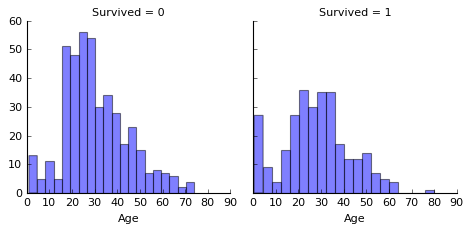

```python
g = sns.FacetGrid(train_df, col='Survived')
g.map(plt.hist, 'Age', bins=20, color = 'blue',alpha=0.5)
```

#### Correlating numerical and ordinal features

我们可以 **结合多个特征** 使用一个plot来识别相关性。这可以通过数值 和 有数值的分类特性来实现

**Observations.**

- Pclass=3 had most passengers, however most did not survive. Confirms our classifying assumption #2.
- Infant passengers in Pclass=2 and Pclass=3 mostly survived. Further qualifies our classifying assumption #2.
- Most passengers in Pclass=1 survived. Confirms our classifying assumption #3.
- Pclass varies in terms of Age distribution of passengers.

**Decisions.**

- Consider Pclass for model training.

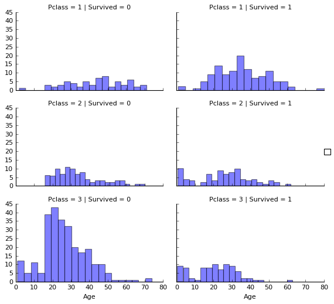

```python
# Survived和 unsurvived画在一张图中
# grid = sns.FacetGrid(train_df, col='Pclass', hue='Survived')
grid = sns.FacetGrid(train_df, col='Survived', row='Pclass', size=2.2, aspect=1.6)
grid.map(plt.hist, 'Age', alpha=0.5, bins=20)
grid.add_legend();
```

#### Correlating categorical features

现在我们可以将分类特性与解决方案目标联系起来

**Decisions.**

- 将Sex feature添加到模型训练中。
- 完成并添加 Embarked feature 到模型训练中。

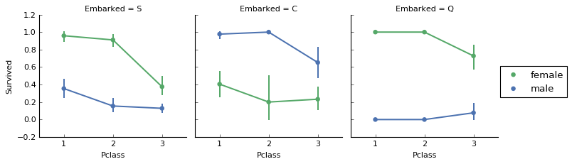

```python
grid = sns.FacetGrid(train_df, col='Embarked')
# grid = sns.FacetGrid(train_df, row='Embarked', size=2.2, aspect=1.6)
grid.map(sns.pointplot, 'Pclass', 'Survived', 'Sex', palette='deep') # Pclass<->Embarked, Pclass<->Survived =>
grid.add_legend()
```

#### Correlating categorical and numerical features (关联分类和numerical features)

我们还可以将分类特性(非数值值)和数值特性关联起来. We can consider correlating Embarked (Categorical non-numeric), Sex (Categorical non-numeric), Fare (Numeric continuous), with Survived (Categorical numeric).

**Observations.**

- Higher fare paying passengers had better survival. Confirms our assumption for creating (#4) fare ranges.
- Port of embarkation correlates with survival rates. Confirms correlating (#1) and completing (#2).

**Decisions.**

- Consider banding Fare feature.

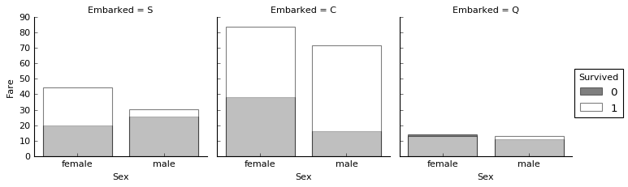

```python
grid = sns.FacetGrid(train_df, col='Embarked', hue='Survived', palette={0: 'k', 1: 'w'})
# grid = sns.FacetGrid(train_df, row='Embarked', col='Survived', size=2.2, aspect=1.6)
grid.map(sns.barplot, 'Sex', 'Fare', alpha=.5, ci=None)
grid.add_legend()
```

### Wrangle data

我们收集了关于我们的数据集和解决方案需求的一些假设和决定。So far we did not have to change a single feature or value to arrive at these. Let us now execute our **decisions and assumptions** for correcting, creating, and completing goals.

#### Correcting by dropping features

This is a good starting goal to execute. By dropping features we are dealing with fewer data points. Speeds up our notebook and eases the analysis.

Based on our assumptions and decisions we want to drop the **Cabin (correcting #2) and Ticket** (correcting #1) features.

我们可以同时在训练数据集和测试数据集上执行操作，以保持一致。

```python
print("Before", train_df.shape, test_df.shape, combine[0].shape, combine[1].shape)

train_df = train_df.drop(['Ticket', 'Cabin'], axis=1)
test_df = test_df.drop(['Ticket', 'Cabin'], axis=1)
combine = [train_df, test_df]

"After", train_df.shape, test_df.shape, combine[0].shape, combine[1].shape
```

```
Before (891, 12) (418, 11) (891, 12) (418, 11)
```

```
('After', (891, 10), (418, 9), (891, 10), (418, 9))
```

#### Creating new feature extracting from existing

我们想要分析是否可以设计出 Name feature 来 提取标题 和 测试 标题和生存之间的相关性 在删除名称和旅客id特性之前。

在以下代码中，我们使用 正则表达式 提取标题特性. The RegEx pattern (\w+.) matches the first word which ends with a dot character within Name feature. The expand=False flag returns a DataFrame.

**Observations.**

When we plot Title, Age, and Survived, we note the following observations.

- Most titles band Age groups accurately. For example: Master title has Age mean of 5 years.
- Survival among Title Age bands varies slightly.
- Certain titles mostly survived (Mme, Lady, Sir) or did not (Don, Rev, Jonkheer).（某些头衔主要是幸存下来的(Mme，女士，先生)，或者没有(唐，牧师，Jonkheer)。）

**Decision.**

- We decide to retain the new Title feature for model training.

```python
for dataset in combine:
    dataset['Title'] = dataset.Name.str.extract(' ([A-Za-z]+)\.', expand=False)

pd.crosstab(train_df['Title'], train_df['Sex'])
```

| Sex Title | female | male |
| --- | --- | --- |
| Capt | 0 | 1 |
| Col | 0 | 2 |
| Countess | 1 | 0 |
| Don | 0 | 1 |
| Dr | 1 | 6 |
| Jonkheer | 0 | 1 |
| Lady | 1 | 0 |
| Major | 0 | 2 |
| Master | 0 | 40 |
| Miss | 182 | 0 |
| Mlle | 2 | 0 |
| Mme | 1 | 0 |
| Mr | 0 | 517 |
| Mrs | 125 | 0 |
| Ms | 1 | 0 |
| Rev | 0 | 6 |
| Sir | 0 | 1 |

We can replace many titles with a more common name or classify them as Rare.

```python
for dataset in combine:
    dataset['Title'] = dataset['Title'].replace(['Lady', 'Countess','Capt', 'Col',
                                                 'Don', 'Dr', 'Major', 'Rev', 'Sir', 'Jonkheer', 'Dona'], 'Rare')

    dataset['Title'] = dataset['Title'].replace('Mlle', 'Miss')
    dataset['Title'] = dataset['Title'].replace('Ms', 'Miss')
    dataset['Title'] = dataset['Title'].replace('Mme', 'Mrs')

train_df[['Title', 'Survived']].groupby(['Title'], as_index=False).mean()
```

|  | Title | Survived |
| --- | --- | --- |
| 0 | Master | 0.575000 |
| 1 | Miss | 0.702703 |
| 2 | Mr | 0.156673 |
| 3 | Mrs | 0.793651 |
| 4 | Rare | 0.347826 |

We can convert the categorical titles to ordinal.(我们可以将分类标题转换为序数。)

```python
title_mapping = {"Mr" : 1, "Miss": 2, "Mrs": 3, "Master": 4, "Rare": 5}
for dataset in combine:
    dataset['Title'] = dataset['Title'].map(title_mapping)
    dataset['Title'] = dataset['Title'].fillna(0)

train_df.head()
```

|  | PassengerId | Survived | Pclass | Name | Sex | Age | SibSp | Parch | Fare | Embarked | Title |
| --- | --- | --- | --- | --- | --- | --- | --- | --- | --- | --- | --- |
| 0 | 1 | 0 | 3 | Braund, Mr. Owen Harris | male | 22.0 | 1 | 0 | 7.2500 | S | 1 |
| 1 | 2 | 1 | 1 | Cumings, Mrs. John Bradley (Florence Briggs Th... | female | 38.0 | 1 | 0 | 71.2833 | C | 3 |
| 2 | 3 | 1 | 3 | Heikkinen, Miss. Laina | female | 26.0 | 0 | 0 | 7.9250 | S | 2 |
| 3 | 4 | 1 | 1 | Futrelle, Mrs. Jacques Heath (Lily May Peel) | female | 35.0 | 1 | 0 | 53.1000 | S | 3 |
| 4 | 5 | 0 | 3 | Allen, Mr. William Henry | male | 35.0 | 0 | 0 | 8.0500 | S | 1 |

现在我们可以安全地从train和test数据集中删除Name feature。我们也不需要train数据集中的乘客id feature。

```python
train_df = train_df.drop(['Name', 'PassengerId'], axis=1)
test_df = test_df.drop(['Name'], axis=1)
combine = [train_df, test_df]
train_df.shape, test_df.shape
```

```
((891, 9), (418, 9))
```

#### Converting a categorical feature

Now we can convert features which contain strings to numerical values.这是大多数模型算法所需要的.这样做也会帮助我们完成目标的完成。

Let us start by converting Sex feature to a new feature called Gender where **female=1 and male=0.**

```python
for dataset in combine:
    dataset['Sex'] = dataset['Sex'].map( {'female': 1, 'male': 0} ).astype(int)

train_df.head()
```

|  | Survived | Pclass | Sex | Age | SibSp | Parch | Fare | Embarked | Title |
| --- | --- | --- | --- | --- | --- | --- | --- | --- | --- |
| 0 | 0 | 3 | 0 | 22.0 | 1 | 0 | 7.2500 | S | 1 |
| 1 | 1 | 1 | 1 | 38.0 | 1 | 0 | 71.2833 | C | 3 |
| 2 | 1 | 3 | 1 | 26.0 | 0 | 0 | 7.9250 | S | 2 |
| 3 | 1 | 1 | 1 | 35.0 | 1 | 0 | 53.1000 | S | 3 |
| 4 | 0 | 3 | 0 | 35.0 | 0 | 0 | 8.0500 | S | 1 |

#### Completing a numerical continuous feature

Now we should start estimating and completing features with **missing or null** values. We will first do this for the **Age feature.**

We can consider three methods to complete a numerical continuous feature.

1. A simple way is to generate random numbers between mean and standard deviation.(在均值和标准差之间生成随机数)
2. More accurate way of guessing missing values is to use other correlated features. In our case we note correlation among **Age, Gender, and Pclass** . Guess Age values using **median values** for Age across sets of Pclass and Gender feature combinations.(猜测年龄值在不同的Pclass和性别特征组合中使用中值。) So, median Age for Pclass=1 and Gender=0, Pclass=1 and Gender=1, and so on...
3. Combine methods 1 and 2. So instead of guessing age values based on median, use random numbers between mean and standard deviation, based on sets of Pclass and Gender combinations.(根据不同的Pclass和性别组合，在均值和标准差之间使用随机数字。)

方法1和3执行结果每次会不一样，所以更喜欢方法2

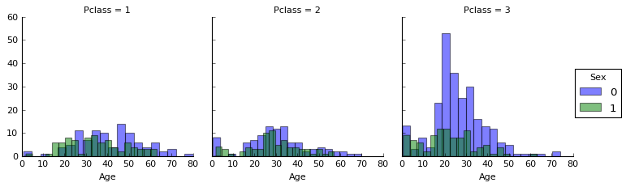

```python
grid = sns.FacetGrid(train_df, col='Pclass', hue='Sex')
# grid = sns.FacetGrid(train_df, row='Pclass', col='Sex', size=2.2, aspect=1.6)  # female: 1, male: 0
grid.map(plt.hist, 'Age', alpha=0.5, bins=20)
grid.add_legend()
```

让我们先准备一个空数组来包含基于Pclass 和 Gender 组合的猜测 的年龄值

```python
guess_ages = np.zeros((2, 3))
guess_ages
```

```
array([[ 0.,  0.,  0.],
       [ 0.,  0.,  0.]])
```

现在我们对 Sex(0或1) 和 Pclass(1、2、3)进行迭代，以计算6种组合的猜测值。

```python
for dataset in combine:
    for i in range(0, 2):
        for j in range(0, 3):
            guess_df = dataset[(dataset['Sex'] == i) &
                               (dataset['Pclass'] == j + 1)]['Age'].dropna()
            # age_mean = guess_df.mean()
            # age_std = guess_df.std()
            # age_guess = rnd.uniform(age_mean - age_std, age_mean + age_std) # 标准化

            age_guess = guess_df.median()

            # Convert random age float to nearest .5 age
            guess_ages[i, j] = int( age_guess / 0.5 + 0.5) * 0.5

    for i in range(0, 2):
        for j in range(0, 3):
            dataset.loc[ (dataset.Age.isnull()) & (dataset.Sex == i) & (dataset.Pclass == j + 1), 'Age'] = guess_ages[i, j]

    dataset['Age'] = dataset['Age'].astype(int)

train_df.head()
```

|  | Survived | Pclass | Sex | Age | SibSp | Parch | Fare | Embarked | Title |
| --- | --- | --- | --- | --- | --- | --- | --- | --- | --- |
| 0 | 0 | 3 | 0 | 22 | 1 | 0 | 7.2500 | S | 1 |
| 1 | 1 | 1 | 1 | 38 | 1 | 0 | 71.2833 | C | 3 |
| 2 | 1 | 3 | 1 | 26 | 0 | 0 | 7.9250 | S | 2 |
| 3 | 1 | 1 | 1 | 35 | 1 | 0 | 53.1000 | S | 3 |
| 4 | 0 | 3 | 0 | 35 | 0 | 0 | 8.0500 | S | 1 |

Let us create Age bands and determine correlations with Survived.

```python
# 查看AgeVBand
train_df['AgeBand'] = pd.cut(train_df['Age'], 5)
train_df[['AgeBand', 'Survived']].groupby(['AgeBand'], as_index=False).mean().sort_values(by='AgeBand', ascending=True)
```

|  | AgeBand | Survived |
| --- | --- | --- |
| 0 | (-0.08, 16] | 0.550000 |
| 1 | (16, 32] | 0.337374 |
| 2 | (32, 48] | 0.412037 |
| 3 | (48, 64] | 0.434783 |
| 4 | (64, 80] | 0.090909 |

Let us replace Age with ordinals based on these bands.

```python
# 用 基于这些Bands 的 顺序值 来代替Age
for dataset in combine:
    dataset.loc[ dataset['Age'] <= 16, 'Age'] = 0
    dataset.loc[(dataset['Age'] > 16) & (dataset['Age'] <= 32), 'Age'] = 1
    dataset.loc[(dataset['Age'] > 32) & (dataset['Age'] <= 48), 'Age'] = 2
    dataset.loc[(dataset['Age'] > 48) & (dataset['Age'] <= 64), 'Age'] = 3
    dataset.loc[ dataset['Age'] > 64, 'Age']
train_df.head()
```

|  | Survived | Pclass | Sex | Age | SibSp | Parch | Fare | Embarked | Title | AgeBand |
| --- | --- | --- | --- | --- | --- | --- | --- | --- | --- | --- |
| 0 | 0 | 3 | 0 | 1 | 1 | 0 | 7.2500 | S | 1 | (16, 32] |
| 1 | 1 | 1 | 1 | 2 | 1 | 0 | 71.2833 | C | 3 | (32, 48] |
| 2 | 1 | 3 | 1 | 1 | 0 | 0 | 7.9250 | S | 2 | (16, 32] |
| 3 | 1 | 1 | 1 | 2 | 1 | 0 | 53.1000 | S | 3 | (32, 48] |
| 4 | 0 | 3 | 0 | 2 | 0 | 0 | 8.0500 | S | 1 | (32, 48] |

```python
train_df = train_df.drop(['AgeBand'], axis=1)
combine = [train_df, test_df]
train_df.head()
```

|  | Survived | Pclass | Sex | Age | SibSp | Parch | Fare | Embarked | Title |
| --- | --- | --- | --- | --- | --- | --- | --- | --- | --- |
| 0 | 0 | 3 | 0 | 1 | 1 | 0 | 7.2500 | S | 1 |
| 1 | 1 | 1 | 1 | 2 | 1 | 0 | 71.2833 | C | 3 |
| 2 | 1 | 3 | 1 | 1 | 0 | 0 | 7.9250 | S | 2 |
| 3 | 1 | 1 | 1 | 2 | 1 | 0 | 53.1000 | S | 3 |
| 4 | 0 | 3 | 0 | 2 | 0 | 0 | 8.0500 | S | 1 |

#### Create new feature combining existing features

我们可以创建一个新特性FamilySize，它将Parch和SibSp结合在一起。这将使我们能够从数据集删除Parch和SibSp。

```python
for dataset in combine:
    dataset['FamilySize'] = dataset['SibSp'] + dataset['Parch'] + 1

train_df[['FamilySize', 'Survived']].groupby(['FamilySize'], as_index=False).mean().sort_values(by='Survived', ascending=False)
```

|  | FamilySize | Survived |
| --- | --- | --- |
| 3 | 4 | 0.724138 |
| 2 | 3 | 0.578431 |
| 1 | 2 | 0.552795 |
| 6 | 7 | 0.333333 |
| 0 | 1 | 0.303538 |
| 4 | 5 | 0.200000 |
| 5 | 6 | 0.136364 |
| 7 | 8 | 0.000000 |
| 8 | 11 | 0.000000 |

We can create another feature called IsAlone.

```python
for dataset in combine:
    dataset['IsAlone'] = 0
    dataset.loc[dataset['FamilySize'] == 1, 'IsAlone'] = 1

train_df[['IsAlone','Survived']].groupby(['IsAlone'], as_index=False).mean()
```

|  | IsAlone | Survived |
| --- | --- | --- |
| 0 | 0 | 0.505650 |
| 1 | 1 | 0.303538 |

Let us drop Parch, SibSp, and FamilySize features in favor of IsAlone.

```python
train_df = train_df.drop(['Parch', 'SibSp', 'FamilySize'], axis=1)
test_df = test_df.drop(['Parch', 'SibSp', 'FamilySize'], axis=1)
combine = [train_df, test_df]

train_df.head()
```

|  | Survived | Pclass | Sex | Age | Fare | Embarked | Title | IsAlone |
| --- | --- | --- | --- | --- | --- | --- | --- | --- |
| 0 | 0 | 3 | 0 | 1 | 7.2500 | S | 1 | 0 |
| 1 | 1 | 1 | 1 | 2 | 71.2833 | C | 3 | 0 |
| 2 | 1 | 3 | 1 | 1 | 7.9250 | S | 2 | 1 |
| 3 | 1 | 1 | 1 | 2 | 53.1000 | S | 3 | 0 |
| 4 | 0 | 3 | 0 | 2 | 8.0500 | S | 1 | 1 |

We can also create an artificial feature combining Pclass and Age.

```python
for dataset in combine:
    dataset['Age*Class'] = dataset.Age * dataset.Pclass

train_df.loc[:, ['Age*Class', 'Age', 'Pclass']].head(10)
```

|  | Age*Class | Age | Pclass |
| --- | --- | --- | --- |
| 0 | 3 | 1 | 3 |
| 1 | 2 | 2 | 1 |
| 2 | 3 | 1 | 3 |
| 3 | 2 | 2 | 1 |
| 4 | 6 | 2 | 3 |
| 5 | 3 | 1 | 3 |
| 6 | 3 | 3 | 1 |
| 7 | 0 | 0 | 3 |
| 8 | 3 | 1 | 3 |
| 9 | 0 | 0 | 2 |

#### Completing a categorical feature

Embarked feature takes S, Q, C values based on port of embarkation. Our training dataset has two missing values. We simply fill these with the most common occurance.

```python
# freq_port = train_df.Embarked.dropna().median()  #采用均值设置missing值
freq_port = train_df.Embarked.dropna().mode()[0]   # 采用出现频率最高的字符赋值给missing的值
freq_port
```

```
'S'
```

```python
for dataset in combine:
    dataset['Embarked'] = dataset['Embarked'].fillna(freq_port)

train_df[['Embarked', 'Survived']].groupby(['Embarked'], as_index=False).mean().sort_values(by='Survived', ascending=False)
```

|  | Embarked | Survived |
| --- | --- | --- |
| 0 | C | 0.553571 |
| 1 | Q | 0.389610 |
| 2 | S | 0.339009 |

#### Converting categorical feature to numeric

We can now convert the EmbarkedFill feature by creating a new numeric Port feature.

```python
for dataset in combine:
    dataset['Embarked'] = dataset['Embarked'].map( {'S': 0, 'C': 1, 'Q': 2} ).astype(int)

train_df.head()
```

|  | Survived | Pclass | Sex | Age | Fare | Embarked | Title | IsAlone | Age*Class |
| --- | --- | --- | --- | --- | --- | --- | --- | --- | --- |
| 0 | 0 | 3 | 0 | 1 | 7.2500 | 0 | 1 | 0 | 3 |
| 1 | 1 | 1 | 1 | 2 | 71.2833 | 1 | 3 | 0 | 2 |
| 2 | 1 | 3 | 1 | 1 | 7.9250 | 0 | 2 | 1 | 3 |
| 3 | 1 | 1 | 1 | 2 | 53.1000 | 0 | 3 | 0 | 2 |
| 4 | 0 | 3 | 0 | 2 | 8.0500 | 0 | 1 | 1 | 6 |

#### Quick completing and converting a numeric feature

请注意，我们并没有创建一个中间新特性，或者做任何进一步的分析，以便与猜测缺失的特性进行相关的分析，因为我们正在替换一个单一的值. 完成目标实现了模型算法对非空值进行操作的期望要求。

We may also want round off the fare to two decimals as it represents currency.(四舍五入成两位数,因为fare是货币)

```python
test_df['Fare'].fillna(test_df['Fare'].dropna().median(), inplace=True)
test_df.head()
```

|  | PassengerId | Pclass | Sex | Age | Fare | Embarked | Title | IsAlone | Age*Class |
| --- | --- | --- | --- | --- | --- | --- | --- | --- | --- |
| 0 | 892 | 3 | 0 | 2 | 7.8292 | 2 | 1 | 1 | 6 |
| 1 | 893 | 3 | 1 | 2 | 7.0000 | 0 | 3 | 0 | 6 |
| 2 | 894 | 2 | 0 | 3 | 9.6875 | 2 | 1 | 1 | 6 |
| 3 | 895 | 3 | 0 | 1 | 8.6625 | 0 | 1 | 1 | 3 |
| 4 | 896 | 3 | 1 | 1 | 12.2875 | 0 | 3 | 0 | 3 |

```python
train_df['FareBand'] = pd.qcut(train_df['Fare'], 4) # qcut()将数据分为若干份
train_df[['FareBand', 'Survived']].groupby(['FareBand'], as_index=False).mean().sort_values(by='FareBand', ascending=True)
```

|  | FareBand | Survived |
| --- | --- | --- |
| 0 | [0, 7.91] | 0.197309 |
| 1 | (7.91, 14.454] | 0.303571 |
| 2 | (14.454, 31] | 0.454955 |
| 3 | (31, 512.329] | 0.581081 |

Convert the Fare feature to **ordinal values** (顺序值) based on the FareBand.

```python
for dataset in combine:
    dataset.loc[ dataset['Fare'] <= 7.91, 'Fare'] = 0
    dataset.loc[(dataset['Fare'] > 7.91) & (dataset['Fare'] <= 14.454), 'Fare'] = 1
    dataset.loc[(dataset['Fare'] > 14.454) & (dataset['Fare'] <= 31), 'Fare'] = 2
    dataset.loc[dataset['Fare'] > 31, 'Fare'] = 3
    dataset['Fare'] = dataset['Fare'].astype(int)

train_df = train_df.drop(['FareBand'], axis=1)
combine = [train_df, test_df]

train_df.head(10)
```

|  | Survived | Pclass | Sex | Age | Fare | Embarked | Title | IsAlone | Age*Class |
| --- | --- | --- | --- | --- | --- | --- | --- | --- | --- |
| 0 | 0 | 3 | 0 | 1 | 0 | 0 | 1 | 0 | 3 |
| 1 | 1 | 1 | 1 | 2 | 3 | 1 | 3 | 0 | 2 |
| 2 | 1 | 3 | 1 | 1 | 1 | 0 | 2 | 1 | 3 |
| 3 | 1 | 1 | 1 | 2 | 3 | 0 | 3 | 0 | 2 |
| 4 | 0 | 3 | 0 | 2 | 1 | 0 | 1 | 1 | 6 |
| 5 | 0 | 3 | 0 | 1 | 1 | 2 | 1 | 1 | 3 |
| 6 | 0 | 1 | 0 | 3 | 3 | 0 | 1 | 1 | 3 |
| 7 | 0 | 3 | 0 | 0 | 2 | 0 | 4 | 0 | 0 |
| 8 | 1 | 3 | 1 | 1 | 1 | 0 | 3 | 0 | 3 |
| 9 | 1 | 2 | 1 | 0 | 2 | 1 | 3 | 0 | 0 |

### Model, predict and solve (终于要开始来建模型了)

现在我们已经准备好训练模型并预测所需的解决方案。有60多种预测建模算法可供选择。我们必须了解问题的类型和解决方案的需求，以便将其缩小到可以评估的少数几种模型。我们的问题是分类和回归问题。我们想要确定输出(存活与否)与其他变量或特性(性别、年龄、端口…)之间的关系。我们也在完善一种机器学习的类别，它被称为“监督学习”，因为我们正在用一个给定的数据集训练我们的模型。有了这两个标准——监督学习+分类和回归，我们可以将模型的选择缩小到少数。这些包括:

- Logistic Regression
- KNN or k-Nearest Neighbors （k-近邻分类）
- Support Vector Machines
- Naive Bayes classifier （朴素贝叶斯分类器）
- Decision Tree
- Random Forrest
- Perceptron (感知机)
- Artificial neural network (人工神经网络)
- RVM or Relevance Vector Machine （关联向量机）

```python
X_train = train_df.drop("Survived", axis=1)  # 这里的X_train是train_df的引用
Y_train = train_df["Survived"]
X_test  = test_df.drop("PassengerId", axis=1).copy()
X_train.shape, Y_train.shape, X_test.shape
```

```
((891, 8), (891,), (418, 8))
```

Logistic回归是在工作流早期运行的一个有用的模型。Logistic回归度量了分类因变量(特征)和一个或多个独立变量(特征)之间的关系，通过一个Logistic函数估计概率，which is the cumulative logistic distribution。引用维基百科

Note the confidence score(置信值) generated by the model based on our training dataset.

```python
# Logistic Regression

logreg = LogisticRegression()
logreg.fit(X_train, Y_train)
Y_pred = logreg.predict(X_test)
acc_log = round(logreg.score(X_train, Y_train) * 100, 2)
acc_log
```

```
80.359999999999999
```

We can use Logistic Regression to validate our assumptions and decisions for feature creating and completing goals. This can be done by calculating the coefficient of the features in the decision function.(我们可以使用逻辑回归来验证我们的假设和决定，以创建和完成目标。这可以通过计算决策函数中the coefficient of the features来完成。)

Positive coefficients increase the log-odds of the response (and thus increase the probability 增加了概率), and negative coefficients decrease the log-odds of the response (and thus decrease the probability).

```python
coeff_df = pd.DataFrame(train_df.columns.delete(0))
coeff_df.columns = ['Feature']
coeff_df["Correlation"] = pd.Series(logreg.coef_[0])

coeff_df.sort_values(by='Correlation', ascending=False)
```

|  | Feature | Correlation |
| --- | --- | --- |
| 1 | Sex | 2.201527 |
| 5 | Title | 0.398234 |
| 2 | Age | 0.287163 |
| 4 | Embarked | 0.261762 |
| 6 | IsAlone | 0.129140 |
| 3 | Fare | -0.085150 |
| 7 | Age*Class | -0.311200 |
| 0 | Pclass | -0.749007 |

Next we model using Support Vector Machines which are supervised learning models with associated learning algorithms that analyze data used for classification and regression analysis.(接下来，我们使用支持向量机建模，它是一种基于相关学习算法的学习模型，分析用于分类和回归分析的数据)

Given a set of training samples, each marked as belonging to one or the other of **two categories**, an SVM training algorithm builds a model that assigns new test samples to one category or the other(SVM训练算法构建一个模型，将新的测试样本分配给一个类别或另一个类别), making it a non-probabilistic binary linear classifier(使其成为非概率的二元线性分类器). Reference Wikipedia.

Note that the model generates **a confidence score** which is higher than Logistics Regression model.

```python
# Support Vevtor Machines

svc = SVC()
svc.fit(X_train, Y_train)
Y_pred = svc.predict(X_test)
acc_svc = round(svc.score(X_train, Y_train) * 100, 2)
acc_svc
```

```
83.840000000000003
```

In pattern recognition, the k-Nearest Neighbors algorithm (or k-NN for short) is a non-parametric method used for classification and regression. (在模式识别中，k最近的近邻算法(简称k - nn)是用于分类和回归的非参数方法。) A sample is classified by a majority vote of its neighbors, with the sample being assigned to the class most common among its k nearest neighbors (k is a positive integer, typically small).If k = 1, then the object is simply assigned to the class of that single nearest neighbor. Reference Wikipedia.

```python
# K-Nearest Neighbors
knn = KNeighborsClassifier(n_neighbors = 3)
knn.fit(X_train, Y_train)
Y_pred = knn.predict(X_test)
acc_knn = round(knn.score(X_train, Y_train) * 100, 2)
acc_knn
```

```
84.739999999999995
```

In machine learning, naive Bayes classifiers are a family of simple probabilistic classifiers(一个简单的概率分类器家族) based on applying Bayes' theorem with strong (naive) independence assumptions between the features(应用Bayes的理论，在特征之间有强大的(朴素的)独立假设）. Naive Bayes classifiers are highly scalable, requiring a number of parameters linear in the number of variables (features) in a learning problem. Reference Wikipedia.（朴素贝叶斯分类器是高度可伸缩的，在学习问题中需要大量参数 线性的数量(特征)）

(模型生成的信心分数是目前评估的模型中最低的) The model generated confidence score is the lowest among the models evaluated so far.

```python
# Gaussian Naive Bayes

gaussian = GaussianNB()
gaussian.fit(X_train, Y_train)
Y_pred = gaussian.predict(X_test)
acc_gaussian = round(gaussian.score(X_train, Y_train) * 100, 2)
acc_gaussian
```

```
72.280000000000001
```

The perceptron is an algorithm for supervised learning of binary classifiers (functions that can decide whether an input, represented by a vector of numbers, belongs to some specific class or not). It is a type of linear classifier, i.e. a classification algorithm that makes its predictions based on a linear predictor function combining a set of weights with the feature vector. The algorithm allows for online learning, in that it processes elements in the training set one at a time. Reference Wikipedia. 感知器是一种对二值分类器进行监督学习的算法(它可以决定一个输入，由一个数字向量表示，是否属于某个特定的类)。它是一种线性分类器，即一种基于线性预测函数的分类算法，将 **一组权重与特征向量** 组合在一起。该算法允许在线学习，在这个过程中，训练中的元素一次只进行一次。引用维基百科。

```python
# Perceptron

perceptron = Perceptron()
perceptron.fit(X_train, Y_train)
Y_pred = perceptron.predict(X_test)
acc_perceptron = round(perceptron.score(X_train, Y_train) * 100, 2)
acc_perceptron
```

```
78.0
```

```python
# Linear SVC

linear_svc = LinearSVC()
linear_svc.fit(X_train, Y_train)
Y_pred = linear_svc.predict(X_test)
acc_linear_svc = round(linear_svc.score(X_train, Y_train) * 100, 2)
acc_linear_svc
```

```
79.010000000000005
```

```python
# Stochastic Gradient Descent 随机梯度下降

sgd = SGDClassifier()
sgd.fit(X_train, Y_train)
Y_pred = sgd.predict(X_test)
acc_sgd = round(sgd.score(X_train, Y_train) * 100, 2)
acc_sgd
```

```
81.030000000000001
```

This model uses a decision tree as a predictive model which maps features (tree branches) to conclusions about the target value (tree leaves). Tree models where the target variable can take a finite(有限的) set of values are called classification trees; in these tree structures, leaves represent class labels and branches represent conjunctions(连接) of features that lead to those class labels. Decision trees where the target variable can take continuous values (typically real numbers) are called regression trees. Reference Wikipedia.

该模型使用决策树作为预测模型，将特征(树分支)映射到目标值(树叶)。目标变量可以取有限值的树模型被称为**分类树**;在这些树状结构中，叶代表类标签，而分支代表指向这些类标签的特征的连接。目标变量可以取连续值(通常为实数)的决策树称为回归树。引用维基百科。

The model confidence score is the highest among models evaluated so far (model confidence score 目前最高)

```python
# Decision Tree

decision_tree = DecisionTreeClassifier()
decision_tree.fit(X_train, Y_train)
Y_pred = decision_tree.predict(X_test)
acc_decision_tree = round(decision_tree.score(X_train, Y_train) * 100, 2)
acc_decision_tree
```

```
86.760000000000005
```

The next model Random Forests is one of the most popular(随机森林是最受欢迎的). Random forests or random decision forests are an ensemble learning method for classification(随机森林或随机决策森林是一种分类的集成学习方法),

regression and other tasks, that operate by constructing a multitude of decision trees (n_estimators=100) at training time and outputting the class that is the mode of the classes (classification) or mean prediction (regression) of the individual trees. Reference Wikipedia. 回归和其他任务, 通过在训练时构建大量的决策树(n_estimators=100), 将个别树的类(分类)或平均值预测(回归)的模式进行输出。

The model confidence score is the highest among models evaluated so far. We decide to use this model's output (Y_pred) for creating our competition submission of results.(置信值目前最高,

```python
# Random Forest

random_forest = RandomForestClassifier(n_estimators=100)
random_forest.fit(X_train, Y_train)
Y_pred = random_forest.predict(X_test)
random_forest.score(X_train, Y_train)
acc_random_forest = round(random_forest.score(X_train, Y_train) * 100, 2)
acc_random_forest
```

```
86.760000000000005
```

### Model evaluation (模型评估)

We can now rank our evaluation of all the models to choose the best one for our problem. While both Decision Tree and Random Forest score the same, we choose to use Random Forest as they correct for decision trees' habit of overfitting to their training set. 我们现在可以对所有的模型进行排名，以选出最适合我们问题的模型。虽然决策树和随机森林都是相同的，但我们选择使用 **随机森林**，因为它调整了决策树在训练集上的过拟合

```python
models = pd.DataFrame({
        'Model': ['Support Vector Machines', 'KNN', 'Logistic Regression',
                 'Random Forest', 'Naive Bayes', 'Perceptron',
                  'Stochastic Gradient Decent', 'Linear SVC',
                  'Decision Tree'],
        'Score': [acc_svc, acc_knn, acc_log,
                 acc_random_forest, acc_gaussian, acc_perceptron,
                 acc_sgd, acc_linear_svc, acc_decision_tree] })
models.sort_values(by='Score', ascending=False)
```

|  | Model | Score |
| --- | --- | --- |
| 3 | Random Forest | 86.76 |
| 8 | Decision Tree | 86.76 |
| 1 | KNN | 84.74 |
| 0 | Support Vector Machines | 83.84 |
| 6 | Stochastic Gradient Decent | 81.03 |
| 2 | Logistic Regression | 80.36 |
| 7 | Linear SVC | 79.01 |
| 5 | Perceptron | 78.00 |
| 4 | Naive Bayes | 72.28 |

```python
submission = pd.DataFrame({
        "PassengerId": test_df['PassengerId'],
        "Survived": Y_pred
    })
submission.to_csv('submission2.csv', index=False)
```